# Nutrient hotspot maps — post-Kona low storm

## Direct comparison: community science vs Hui within 100 m

To directly compare the two independent datasets at the same locations, we matched community science samples to Hui stations using a nearest-neighbour spatial join with a 100 m radius (UTM zone 4N). Both datasets are filtered to post-storm dates (≥ March 14, 2026). The datasets do not sample identically in time — Hui sampled March 18–31 and community science March 28–April 7 — so date difference (CS date − Hui date) is shown as point colour.

```r
# ── Hui post-storm: one row per station-date observation ─────────────────────
hui_match_sf <- bg_hui_loc |>
  filter(year(Date) == 2026, month(Date) == 3,
         Date >= as.Date("2026-03-14"),
         !is.na(Lat), !is.na(Long)) |>
  st_as_sf(coords = c("Long", "Lat"), crs = 4326) |>
  st_transform(32604)

# ── Post-storm community science samples (Maui only, with coordinates) ────────
cs_match_sf <- chem |>
  filter(island == "Maui",
         !is.na(latitude), !is.na(longitude),
         as.Date(collected_hst, tz = "HST") >= as.Date("2026-03-14")) |>
  mutate(cs_date = as.Date(collected_hst, tz = "HST")) |>
  select(sample_id, cs_date, cs_NO3NO2 = NO3NO2, cs_PO4 = PO4,
         cs_SiO2 = SiO2, cs_NH3 = NH3, latitude, longitude) |>
  st_as_sf(coords = c("longitude", "latitude"), crs = 4326) |>
  st_transform(32604)

# ── Spatial join: CS samples within 100 m of each Hui observation ─────────────
matched_pairs <- st_join(
  hui_match_sf,
  cs_match_sf,
  join    = st_is_within_distance,
  dist    = 100
) |>
  st_drop_geometry() |>
  filter(!is.na(sample_id)) |>
  mutate(
    date_diff = as.integer(cs_date - Date),  # positive = WIYW collected after Hui
    dist_label = "≤ 100 m"
  )

cat(glue::glue(
  "{nrow(matched_pairs)} Hui–CS pairs matched ",
  "({n_distinct(matched_pairs$Station)} Hui stations, ",
  "{n_distinct(matched_pairs$sample_id)} CS samples)\n",
  "Date gap range: {min(matched_pairs$date_diff)} to {max(matched_pairs$date_diff)} days\n"
))
```

```
40 Hui–CS pairs matched (26 Hui stations, 40 CS samples)
Date gap range: -2 to 11 days
```

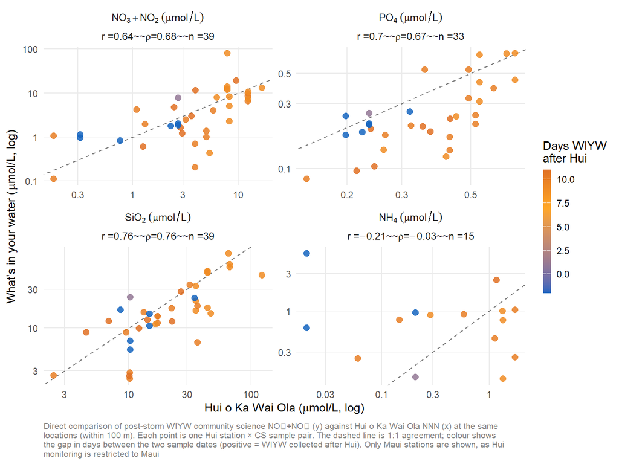

Direct comparison of post-storm community science (What’s in your water) nutrients (y) against Hui o Ka Wai Ola(x) at similar locations (within 100 m). Each point is one Hui station × CS sample pair. The dashed line is 1:1 agreement; colour shows the gap in days between the two sample dates (positive = CS collected after Hui). Only Maui stations are shown, as Hui monitoring is restricted to Maui.

```r
# ── Reshape to long for faceting ──────────────────────────────────────────────
nutrient_map <- tribble(
  ~hui_col,        ~cs_col,      ~label,
  "NNN_umol",      "cs_NO3NO2",  "NO[3]+NO[2]",
  "Phosphate_umol","cs_PO4",     "PO[4]",
  "Silicate_umol", "cs_SiO2",    "SiO[2]",
  "NH4_umol",      "cs_NH3",     "NH[4]"
)

pairs_long <- nutrient_map |>
  purrr::pmap(function(hui_col, cs_col, label) {
    matched_pairs |>
      filter(!is.na(.data[[hui_col]]), !is.na(.data[[cs_col]])) |>
      transmute(
        Station, SiteName, Date, cs_date, date_diff,
        hui_val = .data[[hui_col]],
        cs_val  = .data[[cs_col]],
        nutrient = label
      )
  }) |>
  list_rbind() |>
  mutate(nutrient = factor(nutrient, levels = nutrient_map$label))

# ── Per-nutrient correlations for facet labels ────────────────────────────────
cor_labels <- pairs_long |>
  filter(hui_val > 0, cs_val > 0) |>
  group_by(nutrient) |>
  summarise(
    r   = cor(log10(hui_val), log10(cs_val), method = "pearson",  use = "complete.obs"),
    rho = cor(log10(hui_val), log10(cs_val), method = "spearman", use = "complete.obs"),
    n   = n(),
    .groups = "drop"
  ) |>
  mutate(label = paste0(
    "atop(", nutrient, "~(mu*mol/L), ",
    "paste('r =', ", round(r, 2), ", '~~', rho, '=', ", round(rho, 2), ", '~~n =', ", n, "))"
  ))

cor_labeller <- setNames(cor_labels$label, cor_labels$nutrient)

# ── Plot ──────────────────────────────────────────────────────────────────────
ggplot(pairs_long |>
  filter(hui_val > 0, cs_val > 0), aes(x = hui_val, y = cs_val, color = date_diff)) +
  geom_abline(slope = 1, intercept = 0,
              linetype = "dashed", color = "gray50", linewidth = 0.5) +
  geom_point(size = 2.5, alpha = 0.85) +
  scale_color_gradient2(
    low = "#1565C0", mid = "#FFA726", high = "#B71C1C", midpoint = 7,
    name = "Days WIYW\nafter Hui",
    guide = guide_colorbar(barheight = unit(8, "lines"), barwidth = unit(0.5, "lines"))
  ) +
  scale_x_log10(labels = scales::label_number(drop0trailing = TRUE)) +
  scale_y_log10(labels = scales::label_number(drop0trailing = TRUE)) +
  facet_wrap(~nutrient, scales = "free", ncol = 2,
             labeller = as_labeller(cor_labeller, label_parsed)) +
  labs(
    x = expression("Hui o Ka Wai Ola ("*mu*"mol/L, log)"),
    y = expression("What's in your water ("*mu*"mol/L, log)"),
    caption = str_wrap("Direct comparison of post-storm WIYW community science NO₃+NO₂ (y) against Hui o Ka Wai Ola NNN (x) at the same locations (within 100 m). Each point is one Hui station × CS sample pair. The dashed line is 1:1 agreement; colour shows the gap in days between the two sample dates (positive = WIYW collected after Hui). Only Maui stations are shown, as Hui monitoring is restricted to Maui", width = 120)
  ) +
  theme_minimal(base_size = 11) +
  theme(
    panel.grid.minor   = element_blank(),
    strip.text         = element_text(face = "bold", size = 9.5),
    plot.caption       = element_text(size = 8, color = "gray50", hjust = 0)
  )
```

```r
ggsave(here("output","comparisonHui_WIYW.png"))
```